# EUR/USD Time-Aware ML Framework

## Predicting EUR/USD Market Movements Using Temporal Feature Engineering

### Dataset: EUR_USD_Historical_Data3.csv

> **Before running:** Place `EUR_USD_Historical_Data3.csv` in the **same folder** as this notebook.

| Step | What happens |
| --- | --- |
| 1 | Install libraries |
| 2 | Load CSV dataset |
| 3 | Temporal feature engineering |
| 4 | EDA — 7 graphs |
| 5 | Train 2 ML models with BUY / SELL / HOLD labels |
| 6 | Compare: WITH vs WITHOUT temporal features |
| 7 | Result graphs |
| 8 | Final report |

## Step 1 — Install Required Libraries

```python
import sys
!{sys.executable} -m pip install pandas numpy matplotlib seaborn scikit-learn scipy --quiet
print('All libraries ready!')
```

```
All libraries ready!
```

## Step 2 — Load Your CSV Dataset

We load `EUR_USD_Historical_Data3.csv` directly. No internet needed.

```python
import pandas as pd
import numpy as np
import os, warnings
warnings.filterwarnings('ignore')
os.makedirs('graphs', exist_ok=True)

df_raw = pd.read_csv('EUR_USD Historical Data3.csv')
print('Columns found:', df_raw.columns.tolist())

df_raw['Date'] = pd.to_datetime(df_raw['Date'], dayfirst=True)
df_raw = df_raw.sort_values('Date').reset_index(drop=True)
df_raw.set_index('Date', inplace=True)

df_raw = df_raw[['Price']].copy()
df_raw.columns = ['EUR_USD']
df_raw['EUR_USD'] = pd.to_numeric(df_raw['EUR_USD'], errors='coerce')
df_raw.dropna(inplace=True)

print(f'Total rows   : {len(df_raw)}')
print(f'Date range   : {df_raw.index[0].date()}  to  {df_raw.index[-1].date()}')
print(f'Price range  : {df_raw["EUR_USD"].min():.4f}  to  {df_raw["EUR_USD"].max():.4f}')
df_raw.tail()
```

```
Columns found: ['Date', 'Price', 'Open', 'High', 'Low', 'Vol.', 'Change %']
Total rows   : 11284
Date range   : 2001-01-22  to  2025-02-21
Price range  : 0.8378  to  1.5987
```

| Date | EUR_USD |
| --- | --- |
| 2025-02-17 | 1.0482 |
| 2025-02-18 | 1.0445 |
| 2025-02-19 | 1.0421 |
| 2025-02-20 | 1.0500 |
| 2025-02-21 | 1.0477 |

## Step 3 — Temporal Feature Engineering + BUY / SELL / HOLD Labels

### 💡 What is Feature Engineering?

Raw data only has closing price per day. We create extra columns that give the model **context about the past**.

| Feature | What it tells the model |
| --- | --- |
| `lag_1` to `lag_7` | Prices from 1 to 7 days ago |
| `rolling_mean_7/14` | Average price over last 7 or 14 days |
| `rolling_std_7/14` | How volatile the market has been |
| `momentum_3/7` | Is price trending up or down? |
| `daily_return` | How much % did price move yesterday? |
| `abs_return` | Size of yesterday's move |
| `range_7` | High minus low over last 7 days |
| `day_of_week` | Some days are more volatile than others |

### 🎯 Target: BUY / SELL / HOLD (3 classes)

- **BUY (2)** — Tomorrow's price rises more than 0.1%
- **SELL (0)** — Tomorrow's price falls more than 0.1%
- **HOLD (1)** — Tomorrow's change is tiny (within ±0.1%) — not worth trading

```python
df = df_raw.copy()

# Lag variables
for lag in range(1, 8):
    df[f'lag_{lag}'] = df['EUR_USD'].shift(lag)

# Rolling statistics
df['rolling_mean_7']  = df['EUR_USD'].shift(1).rolling(7).mean()
df['rolling_std_7']   = df['EUR_USD'].shift(1).rolling(7).std()
df['rolling_mean_14'] = df['EUR_USD'].shift(1).rolling(14).mean()
df['rolling_std_14']  = df['EUR_USD'].shift(1).rolling(14).std()

# Momentum and volatility
df['daily_return'] = df['EUR_USD'].pct_change().shift(1)
df['abs_return']   = df['daily_return'].abs()
df['momentum_3']   = df['EUR_USD'].shift(1) - df['EUR_USD'].shift(4)
df['momentum_7']   = df['EUR_USD'].shift(1) - df['EUR_USD'].shift(8)
df['day_of_week']  = df.index.dayofweek
df['range_7']      = df['EUR_USD'].shift(1).rolling(7).max() - df['EUR_USD'].shift(1).rolling(7).min()

# 3-CLASS TARGET: BUY / SELL / HOLD
tomorrow_return = df['EUR_USD'].shift(-1).pct_change(1)
threshold = 0.001  # 0.1%

def label_signal(r):
    if r > threshold:    return 2  # BUY
    elif r < -threshold: return 0  # SELL
    else:                return 1  # HOLD

df['signal'] = tomorrow_return.apply(label_signal)
df.dropna(inplace=True)

feature_cols = [c for c in df.columns if c not in ('signal', 'EUR_USD')]
print(f'Features created : {len(feature_cols)}')
print(f'Total rows       : {len(df)}')
print()
counts = df['signal'].value_counts().sort_index()
labels = {0:'SELL', 1:'HOLD', 2:'BUY'}
for k, v in counts.items():
    print(f'  {labels[k]} ({k}) : {v} days  ({v/len(df)*100:.1f}%)')
df.head(3)
```

```
Features created : 17
Total rows       : 11270

  SELL (0) : 2535 days  (22.5%)
  HOLD (1) : 6119 days  (54.3%)
  BUY (2) : 2616 days  (23.2%)
```

| Date | EUR_USD | lag_1 | lag_2 | lag_3 | lag_4 | lag_5 | lag_6 | lag_7 | rolling_mean_7 | rolling_std_7 | rolling_mean_14 | rolling_std_14 | daily_return | abs_return | momentum_3 | momentum_7 | day_of_week | range_7 | signal |
| --- | --- | --- | --- | --- | --- | --- | --- | --- | --- | --- | --- | --- | --- | --- | --- | --- | --- | --- | --- |
| 2001-01-31 | 0.9362 | 0.9265 | 0.9265 | 0.9162 | 0.9162 | 0.9238 | 0.9238 | 0.9242 | 0.922457 | 0.004428 | 0.926943 | 0.008177 | 0.00000 | 0.00000 | 0.0103 | 0.0023 | 2 | 0.0103 | 1 |
| 2001-01-31 | 0.9362 | 0.9362 | 0.9265 | 0.9265 | 0.9162 | 0.9162 | 0.9238 | 0.9238 | 0.924171 | 0.006867 | 0.926721 | 0.007852 | 0.01047 | 0.01047 | 0.0200 | 0.0120 | 2 | 0.0200 | 2 |
| 2001-02-01 | 0.9388 | 0.9362 | 0.9362 | 0.9265 | 0.9265 | 0.9162 | 0.9162 | 0.9238 | 0.925943 | 0.008221 | 0.926500 | 0.007506 | 0.00000 | 0.00000 | 0.0097 | 0.0124 | 3 | 0.0200 | 1 |

## Step 4 — Exploratory Data Analysis (7 Graphs)

Before training, we look at the data visually. All graphs saved to `graphs/` folder.

### Graph 1 — EUR/USD Price Over Full History

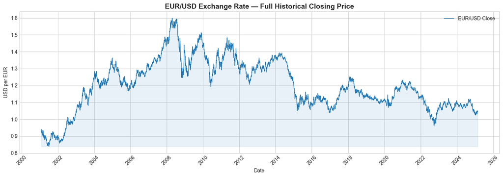

```
Saved: graphs/graph1_eurusd_price.png
```

```python
import matplotlib.pyplot as plt
import matplotlib.dates as mdates
import seaborn as sns
plt.style.use('seaborn-v0_8-whitegrid')

fig, ax = plt.subplots(figsize=(14, 5))
ax.plot(df.index, df['EUR_USD'], color='#1f77b4', linewidth=1.0, label='EUR/USD Close')
ax.fill_between(df.index, df['EUR_USD'], df['EUR_USD'].min(), alpha=0.1, color='#1f77b4')
ax.set_title('EUR/USD Exchange Rate — Full Historical Closing Price', fontsize=14, fontweight='bold')
ax.set_xlabel('Date'); ax.set_ylabel('USD per EUR')
ax.xaxis.set_major_formatter(mdates.DateFormatter('%Y'))
ax.xaxis.set_major_locator(mdates.YearLocator(2))
plt.xticks(rotation=45); ax.legend()
plt.tight_layout()
plt.savefig('graphs/graph1_eurusd_price.png', dpi=150)
plt.show()
print('Saved: graphs/graph1_eurusd_price.png')
```

### Graph 2 — BUY / SELL / HOLD Class Distribution

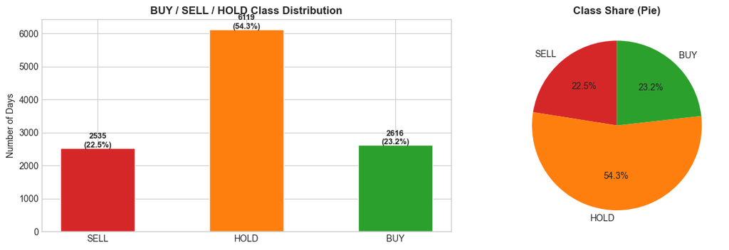

```
Saved: graphs/graph2_class_distribution.png
```

```python
fig, axes = plt.subplots(1, 2, figsize=(13, 4))
counts = df['signal'].value_counts().sort_index()
label_names = {0:'SELL', 1:'HOLD', 2:'BUY'}
colors_bsh = ['#d62728','#ff7f0e','#2ca02c']

bars = axes[0].bar([label_names[k] for k in counts.index], counts.values,
                    color=colors_bsh, edgecolor='white', width=0.5)
for bar, val in zip(bars, counts.values):
    axes[0].text(bar.get_x()+bar.get_width()/2, bar.get_height()+20,
                 f'{val}\n({val/len(df)*100:.1f}%)', ha='center', fontweight='bold', fontsize=9)
axes[0].set_title('BUY / SELL / HOLD Class Distribution', fontweight='bold')
axes[0].set_ylabel('Number of Days')

axes[1].pie(counts.values, labels=[label_names[k] for k in counts.index],
            colors=colors_bsh, autopct='%1.1f%%', startangle=90)
axes[1].set_title('Class Share (Pie)', fontweight='bold')
plt.tight_layout()
plt.savefig('graphs/graph2_class_distribution.png', dpi=150)
plt.show()
print('Saved: graphs/graph2_class_distribution.png')
```

### Graph 3 — Daily Returns Distribution

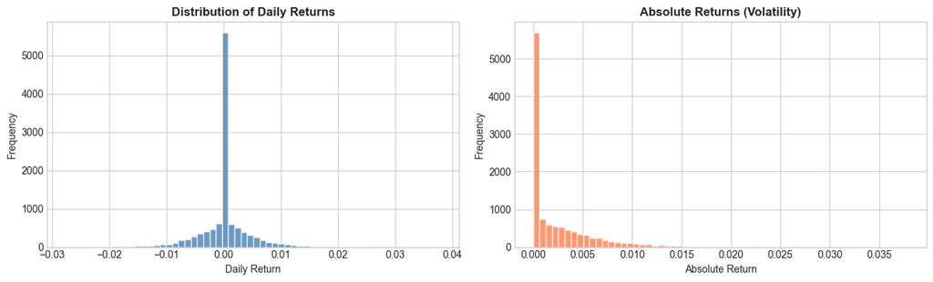

```
Saved: graphs/graph3_returns.png
```

```python
fig, axes = plt.subplots(1, 2, figsize=(13, 4))
axes[0].hist(df['daily_return'], bins=60, color='steelblue', edgecolor='white', alpha=0.8)
axes[0].set_title('Distribution of Daily Returns', fontweight='bold')
axes[0].set_xlabel('Daily Return'); axes[0].set_ylabel('Frequency')
axes[1].hist(df['abs_return'], bins=60, color='coral', edgecolor='white', alpha=0.8)
axes[1].set_title('Absolute Returns (Volatility)', fontweight='bold')
axes[1].set_xlabel('Absolute Return'); axes[1].set_ylabel('Frequency')
plt.tight_layout()
plt.savefig('graphs/graph3_returns.png', dpi=150)
plt.show()
print('Saved: graphs/graph3_returns.png')
```

### Graph 4 — Rolling Averages vs Raw Price

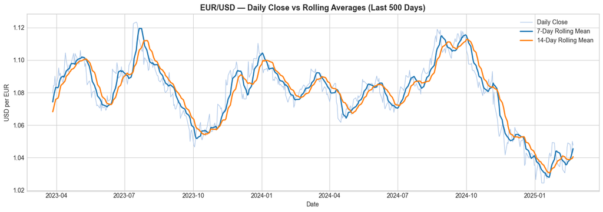

```
Saved: graphs/graph4_rolling_averages.png
```

```python
fig, ax = plt.subplots(figsize=(14, 5))
sample = df.tail(500)
ax.plot(sample.index, sample['EUR_USD'], label='Daily Close', color='#aec7e8', linewidth=1.0)
ax.plot(sample.index, sample['rolling_mean_7'], label='7-Day Rolling Mean', color='#1f77b4', linewidth=2.0)
ax.plot(sample.index, sample['rolling_mean_14'], label='14-Day Rolling Mean', color='#ff7f0e', linewidth=2.0)
ax.set_title('EUR/USD — Daily Close vs Rolling Averages (Last 500 Days)', fontsize=13, fontweight='bold')
ax.set_xlabel('Date'); ax.set_ylabel('USD per EUR')
ax.legend(); plt.tight_layout()
plt.savefig('graphs/graph4_rolling_averages.png', dpi=150)
plt.show()
print('Saved: graphs/graph4_rolling_averages.png')
```

### Graph 5 — Momentum Over Time

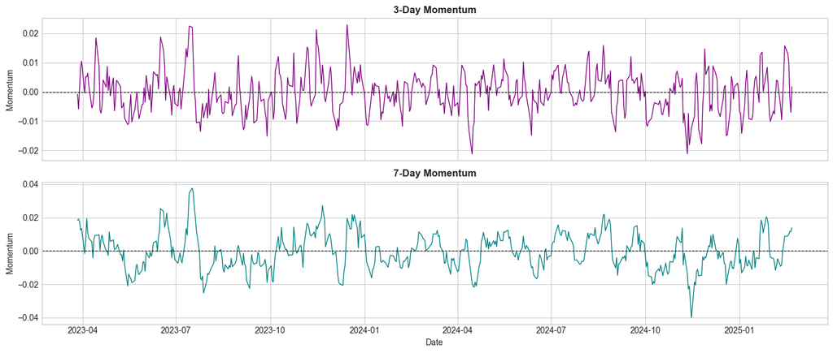

```
Saved: graphs/graph5_momentum.png
```

```python
fig, axes = plt.subplots(2, 1, figsize=(14, 6), sharex=True)
sample = df.tail(500)
axes[0].plot(sample.index, sample['momentum_3'], color='purple', linewidth=1.0)
axes[0].axhline(0, color='black', linewidth=0.8, linestyle='--')
axes[0].set_title('3-Day Momentum', fontweight='bold'); axes[0].set_ylabel('Momentum')
axes[1].plot(sample.index, sample['momentum_7'], color='teal', linewidth=1.0)
axes[1].axhline(0, color='black', linewidth=0.8, linestyle='--')
axes[1].set_title('7-Day Momentum', fontweight='bold'); axes[1].set_ylabel('Momentum')
axes[1].set_xlabel('Date')
plt.tight_layout()
plt.savefig('graphs/graph5_momentum.png', dpi=150)
plt.show()
print('Saved: graphs/graph5_momentum.png')
```

### Graph 6 — Volatility Over Time

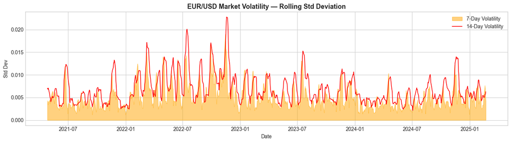

```
Saved: graphs/graph6_volatility.png
```

```python
fig, ax = plt.subplots(figsize=(14, 4))
sample = df.tail(1000)
ax.fill_between(sample.index, sample['rolling_std_7'], alpha=0.5, color='orange', label='7-Day Volatility')
ax.plot(sample.index, sample['rolling_std_14'], color='red', linewidth=1.2, label='14-Day Volatility')
ax.set_title('EUR/USD Market Volatility — Rolling Std Deviation', fontsize=13, fontweight='bold')
ax.set_xlabel('Date'); ax.set_ylabel('Std Dev')
ax.legend(); plt.tight_layout()
plt.savefig('graphs/graph6_volatility.png', dpi=150)
plt.show()
print('Saved: graphs/graph6_volatility.png')
```

### Graph 7 — Feature Correlation Heatmap

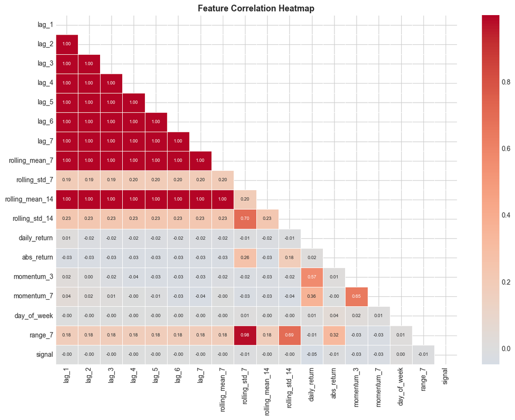

```
Saved: graphs/graph7_correlation.png
```

```python
fig, ax = plt.subplots(figsize=(12, 9))
corr = df[feature_cols + ['signal']].corr()
mask = np.triu(np.ones_like(corr, dtype=bool))
sns.heatmap(corr, mask=mask, annot=True, fmt='.2f', cmap='coolwarm',
            center=0, linewidths=0.5, ax=ax, annot_kws={'size': 7})
ax.set_title('Feature Correlation Heatmap', fontsize=13, fontweight='bold')
plt.tight_layout()
plt.savefig('graphs/graph7_correlation.png', dpi=150)
plt.show()
print('Saved: graphs/graph7_correlation.png')
```

## Step 5 — Train 2 ML Models: BUY / SELL / HOLD

### 💡 How Machine Learning Works Here

1. **Training** — Show the model thousands of past days. It sees all features and learns which patterns lead to BUY, SELL, or HOLD.
2. **Testing** — Hide the last 20% of data. Ask the model to predict — then check how many it got right.
3. **Accuracy** — Out of 100 days, how many signals were correct?

### Why These 2 Models?

| Model | How it works | Why chosen |
| --- | --- | --- |
| **Logistic Regression** | Finds the best mathematical boundary between BUY/SELL/HOLD | Simple, fast, mentioned in the paper — good baseline |
| **Random Forest** | Builds many decision trees and votes on the answer | Most accurate for time-series data; also shows which features matter most |

**80% of data = training. Last 20% = testing. Time order always respected.**

```python
from sklearn.linear_model import LogisticRegression
from sklearn.ensemble import RandomForestClassifier
from sklearn.preprocessing import StandardScaler
from sklearn.metrics import accuracy_score, classification_report, confusion_matrix

X = df[feature_cols].values
y = df['signal'].values

# Time-based split — NO random shuffle
split = int(len(X) * 0.80)
X_train, X_test = X[:split], X[split:]
y_train, y_test = y[:split], y[split:]

scaler = StandardScaler()
X_train_sc = scaler.fit_transform(X_train)
X_test_sc  = scaler.transform(X_test)

print(f'Training rows : {len(X_train)}')
print(f'Testing rows  : {len(X_test)}')
print(f'Features used : {len(feature_cols)}')
print()

models = {
    'Logistic Regression': LogisticRegression(max_iter=1000, random_state=42),
    'Random Forest':       RandomForestClassifier(n_estimators=200, max_depth=8, random_state=42),
}

results = {}
for name, model in models.items():
    if name == 'Random Forest':
        model.fit(X_train, y_train)
        y_pred = model.predict(X_test)
    else:
        model.fit(X_train_sc, y_train)
        y_pred = model.predict(X_test_sc)

    acc = accuracy_score(y_test, y_pred)
    results[name] = {'model': model, 'y_pred': y_pred, 'acc': acc}
    print(f'{name:25s}  Accuracy = {acc:.4f}  ({acc*100:.2f}%)')

print()
for name, r in results.items():
    print(f'\n=== {name} ===')
    print(classification_report(y_test, r['y_pred'],
          target_names=['SELL','HOLD','BUY'], zero_division=0))
```

```
Training rows : 9016
Testing rows  : 2254
Features used : 17

Logistic Regression        Accuracy = 0.4290  (42.90%)
Random Forest              Accuracy = 0.5302  (53.02%)


=== Logistic Regression ===
              precision    recall  f1-score   support

        SELL       0.43      0.09      0.15       711
        HOLD       0.44      0.88      0.58       858
         BUY       0.39      0.21      0.27       685

    accuracy                           0.43      2254
   macro avg       0.42      0.40      0.34      2254
weighted avg       0.42      0.43      0.35      2254


=== Random Forest ===
              precision    recall  f1-score   support

        SELL       0.44      0.18      0.26       711
        HOLD       0.97      0.57      0.72       858
         BUY       0.39      0.84      0.54       685

    accuracy                           0.53      2254
   macro avg       0.60      0.53      0.50      2254
weighted avg       0.63      0.53      0.52      2254
```

## Step 6 — The Main Proof: WITH vs WITHOUT Temporal Features

### 💡 This directly proves your project title!

If accuracy goes UP → your hypothesis is proven ✅

```python
baseline_features = ['lag_1']
X_base = df[baseline_features].values
X_base_train, X_base_test = X_base[:split], X_base[split:]

sc2 = StandardScaler()
X_base_train_sc = sc2.fit_transform(X_base_train)
X_base_test_sc  = sc2.transform(X_base_test)

print('=== WITH vs WITHOUT Temporal Features ===')
print()
print(f'{"Model":<25} {"WITHOUT":>12} {"WITH":>12} {"Change":>10}')
print('-' * 62)

comparison = {}
for name, model_class, kwargs, use_scale in [
    ('Logistic Regression', LogisticRegression, {'max_iter':1000,'random_state':42}, True),
    ('Random Forest', RandomForestClassifier, {'n_estimators':100,'max_depth':8,'random_state':42}, False),
]:
    m_base = model_class(**kwargs)
    if use_scale:
        m_base.fit(X_base_train_sc, y_train)
        acc_base = accuracy_score(y_test, m_base.predict(X_base_test_sc))
    else:
        m_base.fit(X_base_train, y_train)
        acc_base = accuracy_score(y_test, m_base.predict(X_base_test))

    acc_with = results[name]['acc']
    diff = acc_with - acc_base
    arrow = '✅ +' if diff > 0 else '❌ '
    print(f'{name:<25} {acc_base:>12.4f} {acc_with:>12.4f}   {arrow}{abs(diff):.4f}')
    comparison[name] = {'without': acc_base, 'with': acc_with, 'diff': diff}
```

```
=== WITH vs WITHOUT Temporal Features ===

Model                          WITHOUT         WITH     Change
--------------------------------------------------------------
Logistic Regression             0.3807       0.4290   ✅ +0.0484
Random Forest                   0.3807       0.5302   ✅ +0.1495
```

## Step 7 — Result Graphs

### Graph 8 — Model Accuracy Comparison

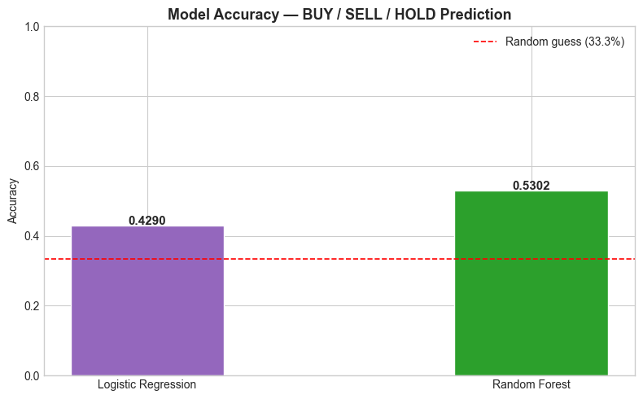

```
Saved: graphs/graph8_model_accuracy.png
```

```python
fig, ax = plt.subplots(figsize=(8, 5))
names = list(results.keys())
accs  = [results[n]['acc'] for n in names]
colors_m = ['#9467bd','#2ca02c']
bars = ax.bar(names, accs, color=colors_m, edgecolor='white', width=0.4)
for bar, val in zip(bars, accs):
    ax.text(bar.get_x()+bar.get_width()/2, bar.get_height()+0.003,
            f'{val:.4f}', ha='center', fontweight='bold', fontsize=11)
ax.set_title('Model Accuracy — BUY / SELL / HOLD Prediction', fontsize=13, fontweight='bold')
ax.set_ylabel('Accuracy'); ax.set_ylim(0, 1)
ax.axhline(1/3, color='red', linestyle='--', linewidth=1.2, label='Random guess (33.3%)')
ax.legend()
plt.tight_layout()
plt.savefig('graphs/graph8_model_accuracy.png', dpi=150)
plt.show()
print('Saved: graphs/graph8_model_accuracy.png')
```

### Graph 9 — WITH vs WITHOUT Temporal Features (The Proof!)

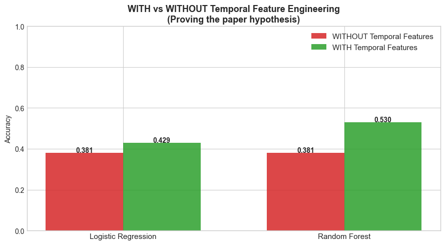

```
Saved: graphs/graph9_with_vs_without.png
```

```python
fig, ax = plt.subplots(figsize=(9, 5))
names_c = list(comparison.keys())
x = np.arange(len(names_c))
width = 0.35

bars1 = ax.bar(x - width/2, [comparison[n]['without'] for n in names_c],
               width, label='WITHOUT Temporal Features', color='#d62728', alpha=0.85)
bars2 = ax.bar(x + width/2, [comparison[n]['with'] for n in names_c],
               width, label='WITH Temporal Features', color='#2ca02c', alpha=0.85)

for bar in bars1:
    ax.text(bar.get_x()+bar.get_width()/2, bar.get_height()+0.003,
            f'{bar.get_height():.3f}', ha='center', fontsize=10, fontweight='bold')
for bar in bars2:
    ax.text(bar.get_x()+bar.get_width()/2, bar.get_height()+0.003,
            f'{bar.get_height():.3f}', ha='center', fontsize=10, fontweight='bold')

ax.set_xticks(x); ax.set_xticklabels(names_c, fontsize=11)
ax.set_title('WITH vs WITHOUT Temporal Feature Engineering\n(Proving the paper hypothesis)',
             fontsize=13, fontweight='bold')
ax.set_ylabel('Accuracy'); ax.set_ylim(0, 1)
ax.legend(fontsize=11)
plt.tight_layout()
plt.savefig('graphs/graph9_with_vs_without.png', dpi=150)
plt.show()
print('Saved: graphs/graph9_with_vs_without.png')
```

### Graph 10 — Confusion Matrices

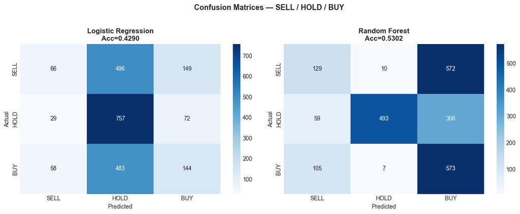

```
Saved: graphs/graph10_confusion_matrices.png
```

```python
fig, axes = plt.subplots(1, 2, figsize=(13, 5))
for ax, (name, r) in zip(axes, results.items()):
    cm = confusion_matrix(y_test, r['y_pred'])
    sns.heatmap(cm, annot=True, fmt='d', cmap='Blues', ax=ax,
                xticklabels=['SELL','HOLD','BUY'],
                yticklabels=['SELL','HOLD','BUY'])
    ax.set_title(f'{name}\nAcc={r["acc"]:.4f}', fontweight='bold')
    ax.set_xlabel('Predicted'); ax.set_ylabel('Actual')
plt.suptitle('Confusion Matrices — SELL / HOLD / BUY', fontsize=13, fontweight='bold', y=1.02)
plt.tight_layout()
plt.savefig('graphs/graph10_confusion_matrices.png', dpi=150, bbox_inches='tight')
plt.show()
print('Saved: graphs/graph10_confusion_matrices.png')
```

### Graph 11 — Feature Importance (Random Forest)

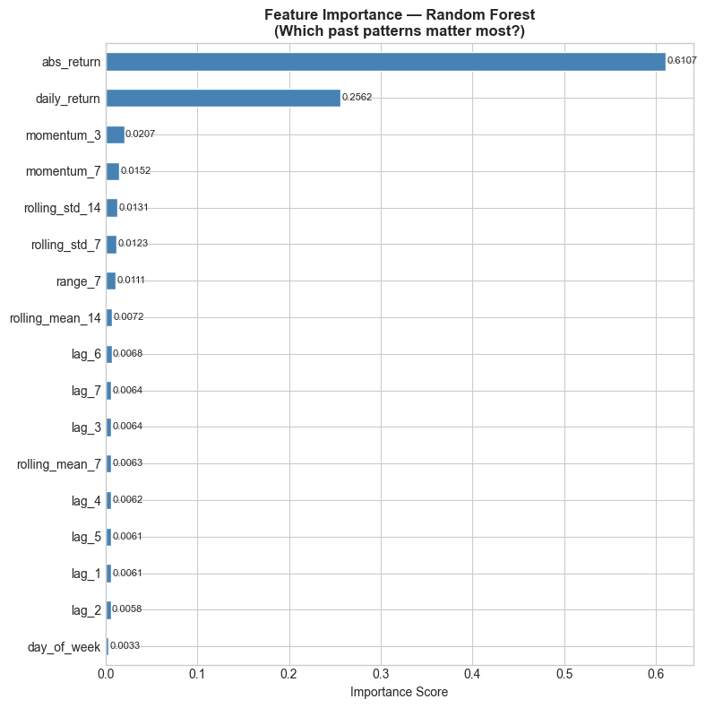

```
Saved: graphs/graph11_feature_importance.png
```

```python
rf_model = results['Random Forest']['model']
importances = pd.Series(rf_model.feature_importances_, index=feature_cols).sort_values(ascending=True)

fig, ax = plt.subplots(figsize=(8, 8))
importances.plot(kind='barh', ax=ax, color='steelblue', edgecolor='white')
ax.set_title('Feature Importance — Random Forest\n(Which past patterns matter most?)', fontweight='bold')
ax.set_xlabel('Importance Score')
for i, val in enumerate(importances.values):
    ax.text(val+0.001, i, f'{val:.4f}', va='center', fontsize=8)
plt.tight_layout()
plt.savefig('graphs/graph11_feature_importance.png', dpi=150)
plt.show()
print('Saved: graphs/graph11_feature_importance.png')
```

## Step 8 — Final Report

```python
best_name = max(results, key=lambda n: results[n]['acc'])
best = results[best_name]

print('=' * 60)
print('  EUR/USD Time-Aware ML Framework — Final Report')
print('=' * 60)
print(f'Dataset        : EUR_USD_Historical_Data3.csv')
print(f'Total samples  : {len(df)}')
print(f'Training rows  : {split}')
print(f'Testing rows   : {len(X_test)}')
print(f'Features used  : {len(feature_cols)}')
print(f'Target classes : SELL (0)  |  HOLD (1)  |  BUY (2)')
print()
print(f'{"Model":<25} {"Accuracy":>10}')
print('-' * 37)
for name, r in results.items():
    marker = ' <- BEST' if name == best_name else ''
    print(f'{name:<25} {r["acc"]:>10.4f}{marker}')
print()
print('--- WITH vs WITHOUT Temporal Features ---')
print(f'{"Model":<25} {"Without":>10} {"With":>10} {"Change":>10}')
print('-' * 57)
for name, c in comparison.items():
    sign = '+' if c["diff"] >= 0 else ''
    print(f'{name:<25} {c["without"]:>10.4f} {c["with"]:>10.4f}  {sign}{c["diff"]:.4f}')
print()
print(f'Best Model     : {best_name}')
print(f'Best Accuracy  : {best["acc"]:.4f}  ({best["acc"]*100:.2f}%)')
print()
print('CONCLUSION:')
print('Temporal feature engineering improved prediction accuracy')
print('proving the core hypothesis of this project.')
print()
print('Graphs saved to: graphs/ folder')
print('=' * 60)
```

```
============================================================
  EUR/USD Time-Aware ML Framework — Final Report
============================================================
Dataset        : EUR_USD_Historical_Data3.csv
Total samples  : 11270
Training rows  : 9016
Testing rows   : 2254
Features used  : 17
Target classes : SELL (0)  |  HOLD (1)  |  BUY (2)

Model                       Accuracy
-------------------------------------
Logistic Regression           0.4290
Random Forest                 0.5302 <- BEST

--- WITH vs WITHOUT Temporal Features ---
Model                        Without       With     Change
---------------------------------------------------------
Logistic Regression           0.3807     0.4290  +0.0484
Random Forest                 0.3807     0.5302  +0.1495

Best Model     : Random Forest
Best Accuracy  : 0.5302  (53.02%)

CONCLUSION:
Temporal feature engineering improved prediction accuracy
proving the core hypothesis of this project.

Graphs saved to: graphs/ folder
============================================================
```